# amazon billing management

Sourabh, Huy, Peter, Haodi, Huibo

August 05, 2019

```r
# Clear environment of variables and functions
rm(list = ls(all = TRUE))
# Clear environmet of packages
if(is.null(sessionInfo()$otherPkgs) == FALSE)lapply(paste("package:", names(sessionInfo()$otherPkgs), sep=""), detach, character.only = TRUE, unload = TRUE)
```

```r
# adding library
library(tidyverse)
library(GGally)
library(gridExtra)
library("readxl")
library(janitor)
library(stringr)
library(aod)
```

```r
library(ggplot2)
library(stringi)
library(reshape2)
full_dta <- read_csv('full_dta.csv')
```

# Optional for splitting data into training and test sets

```r
# Training and validation sets
training <- subset(full_dta, full_dta$month == "04" | full_dta$month == "05")
validation <- subset(full_dta, full_dta$month == "06")
index <- sample(1:nrow(training), 3000, replace = TRUE)
training <- training[index,]
training <- training[!is.na(training$month), ]
training$Visualize <- ifelse(training$Visualize == "Yes", 1,0)
training$Alert <- ifelse(training$Alert == "Yes", 1,0)
training$Report <- ifelse(training$Report == "Yes", 1,0)
summary(training)
```

```
##  Billing_month        Customer_ID        Registration_date
##  Min.   :2019-04-01   Length:3000        Min.   :2004-11-02
##  1st Qu.:2019-04-01   Class :character   1st Qu.:2013-05-07
##  Median :2019-05-01   Mode  :character   Median :2015-05-19
##  Mean   :2019-04-16                      Mean   :2015-01-01
##  3rd Qu.:2019-05-01                      3rd Qu.:2017-01-19
##  Max.   :2019-05-01                      Max.   :2019-05-10
##   product_id        Billed_amount         month
##  Length:3000        Min.   :    0.00   Length:3000
##  Class :character   1st Qu.:    0.00   Class :character
##  Mode  :character   Median :    1.57   Mode  :character
##                     Mean   :  446.50
##                     3rd Qu.:  103.23
##                     Max.   :59275.73
##     Month           Customer_size        Geo_Code           Visualize
##  Length:3000        Length:3000        Length:3000        Min.   :0.0000
##  Class :character   Class :character   Class :character   1st Qu.:0.0000
##  Mode  :character   Mode  :character   Mode  :character   Median :0.0000
##                                                           Mean   :0.3353
##                                                           3rd Qu.:1.0000
##                                                           Max.   :1.0000
##      Alert             Report          age_year
##  Min.   :0.00000   Min.   :0.00000   Length:3000
##  1st Qu.:0.00000   1st Qu.:0.00000   Class :character
##  Median :0.00000   Median :0.00000   Mode  :character
##  Mean   :0.08067   Mean   :0.08433
##  3rd Qu.:0.00000   3rd Qu.:0.00000
##  Max.   :1.00000   Max.   :1.00000
```

# Variable by month

## What are the counts, Billed_amounts, money per by Customer_size?

```r
Customer_size_group <- full_dta %>%
  group_by(Customer_size, Month) %>%
  summarise(count = n(),
            total_billed_amt = sum(Billed_amount),
            billed_per_cust = total_billed_amt / count) %>%
  arrange(-total_billed_amt)
```

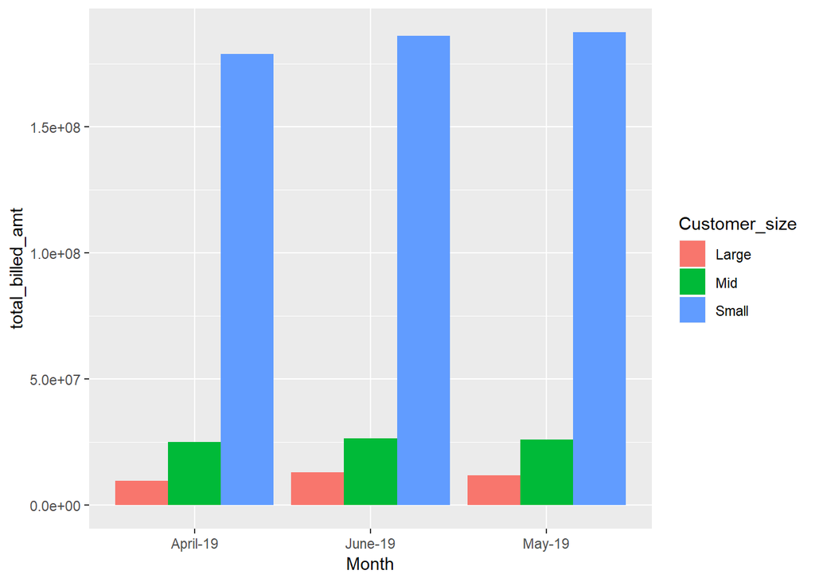

```r
ggplot(data = Customer_size_group, aes(x = Month, y = total_billed_amt, fill = Customer_size)) +
  geom_bar(stat = "identity", position = "dodge")
```

## What are the counts, Billed_amounts, money per by Geo_Code?

```r
Geo_Code_group <- full_dta %>%
  group_by(Geo_Code, Month) %>%
  summarise(count = n(),
            total_billed_amt = sum(Billed_amount),
            billed_per_cust = total_billed_amt / count) %>%
  arrange(-total_billed_amt)
```

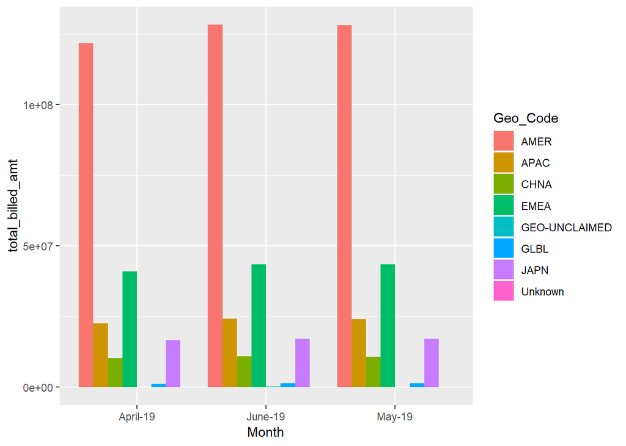

```r
ggplot(data = Geo_Code_group, aes(x = Month, y = total_billed_amt, fill = Geo_Code)) +
  geom_bar(stat = "identity", position = "dodge")
```

## What are the counts, Billed_amounts, money per by Visualize?

```r
Visualize_group <- full_dta %>%
  group_by(Visualize, Month) %>%
  summarise(count = n(),
            total_billed_amt = sum(Billed_amount),
            billed_per_cust = total_billed_amt / count) %>%
  arrange(-total_billed_amt)
```

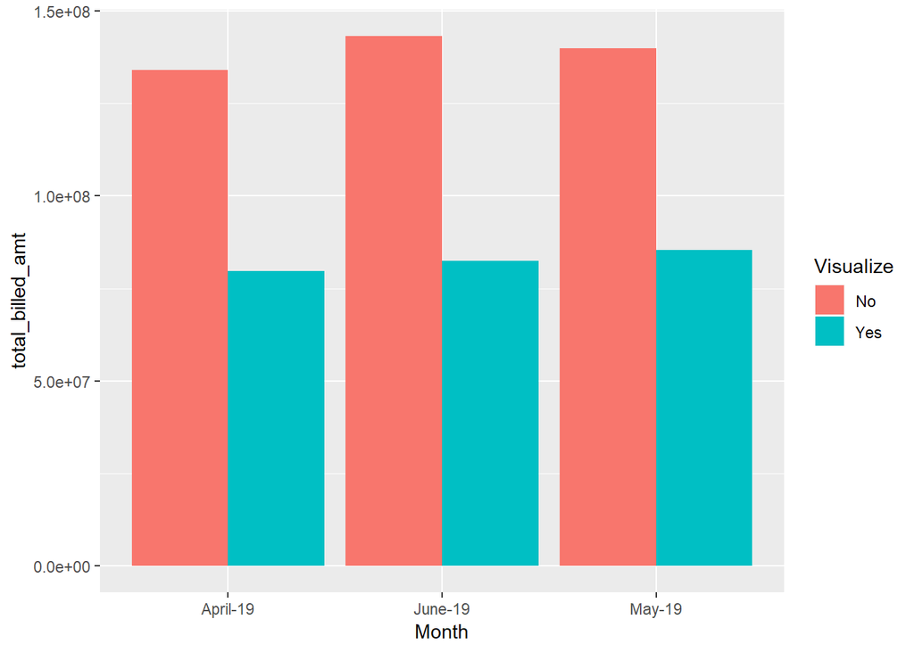

```r
ggplot(data = Visualize_group, aes(x = Month, y = total_billed_amt, fill = Visualize)) +
  geom_bar(stat = "identity", position = "dodge")
```

## What are the counts, Billed_amounts, money per by Alert?

```r
Alert_group <- full_dta %>%
  group_by(Alert, Month) %>%
  summarise(count = n(),
            total_billed_amt = sum(Billed_amount),
            billed_per_cust = total_billed_amt / count) %>%
  arrange(-total_billed_amt)
```

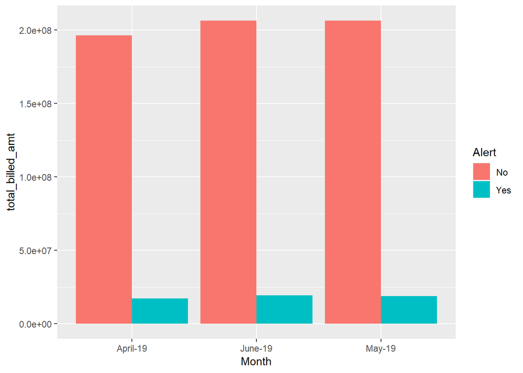

```r
ggplot(data = Alert_group, aes(x = Month, y = total_billed_amt, fill = Alert)) +
  geom_bar(stat = "identity", position = "dodge")
```

## What are the counts, Billed_amounts, money per by Report?

```r
Report_group <- full_dta %>%
  group_by(Report, Month) %>%
  summarise(count = n(),
            total_billed_amt = sum(Billed_amount),
            billed_per_cust = total_billed_amt / count) %>%
  arrange(-total_billed_amt)
```

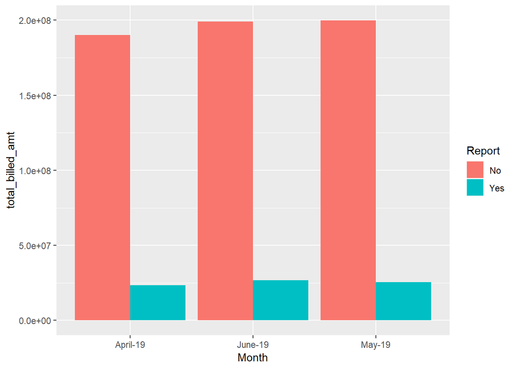

```r
ggplot(data = Report_group, aes(x = Month, y = total_billed_amt, fill = Report)) +
  geom_bar(stat = "identity", position = "dodge")
```

## What are the counts, Billed_amounts, money per by age_year?

```r
age_year_group <- full_dta %>%
  group_by(age_year, Month) %>%
  summarise(count = n(),
            total_billed_amt = sum(Billed_amount),
            billed_per_cust = total_billed_amt / count) %>%
  arrange(-total_billed_amt)
```

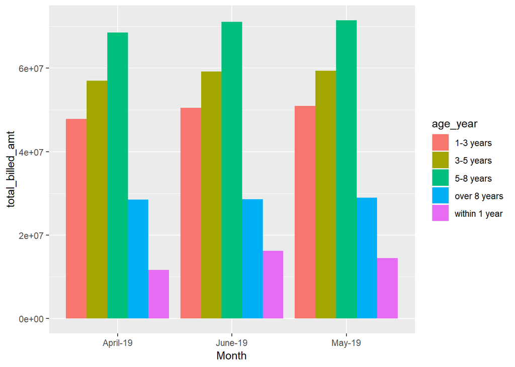

```r
ggplot(data = age_year_group, aes(x = Month, y = total_billed_amt, fill = age_year)) +
  geom_bar(stat = "identity", position = "dodge")
```

# Variables with Visualize, Alert, and Report percentages

## Usage Percentages by Customer_size

```r
Pct_by_Customer_size <- full_dta %>%
  group_by(Customer_size) %>%
  summarise(count = n(),
            viz_yes = sum(Visualize == "Yes"),
            viz_pct = (viz_yes / count) * 100,
            alert_yes = sum(Alert == "Yes"),
            alert_pct = (alert_yes / count) * 100,
            report_yes = sum(Report == "Yes"),
            report_pct = (report_yes / count) * 100)
```

```r
Pct_by_Customer_size_melt <- melt(Pct_by_Customer_size, id = "Customer_size", measure = c("viz_pct", "alert_pct", "report_pct"))
```

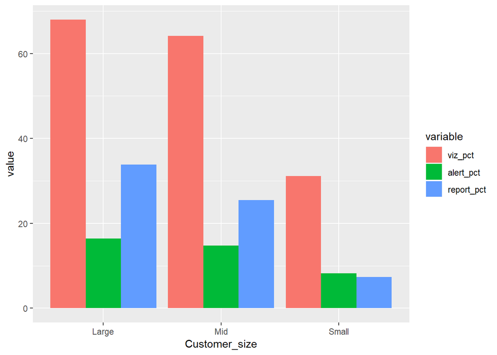

```r
ggplot(data = Pct_by_Customer_size_melt, aes(x = Customer_size, y = value, fill = variable)) +
  geom_bar(stat = "identity", position = "dodge")
```

- As the companies get larger, the usage percentages increase

## Usage Percentages by Geo_Code

```r
Pct_by_Geo_Code <- full_dta %>%
  group_by(Geo_Code) %>%
  summarise(count = n(),
            viz_yes = sum(Visualize == "Yes"),
            viz_pct = viz_yes / count,
            alert_yes = sum(Alert == "Yes"),
            alert_pct = alert_yes / count,
            report_yes = sum(Report == "Yes"),
            report_pct = report_yes / count)
```

```r
Pct_by_Geo_Code_melt <- melt(Pct_by_Geo_Code, id = "Geo_Code", measure = c("viz_pct", "alert_pct", "report_pct"))
```

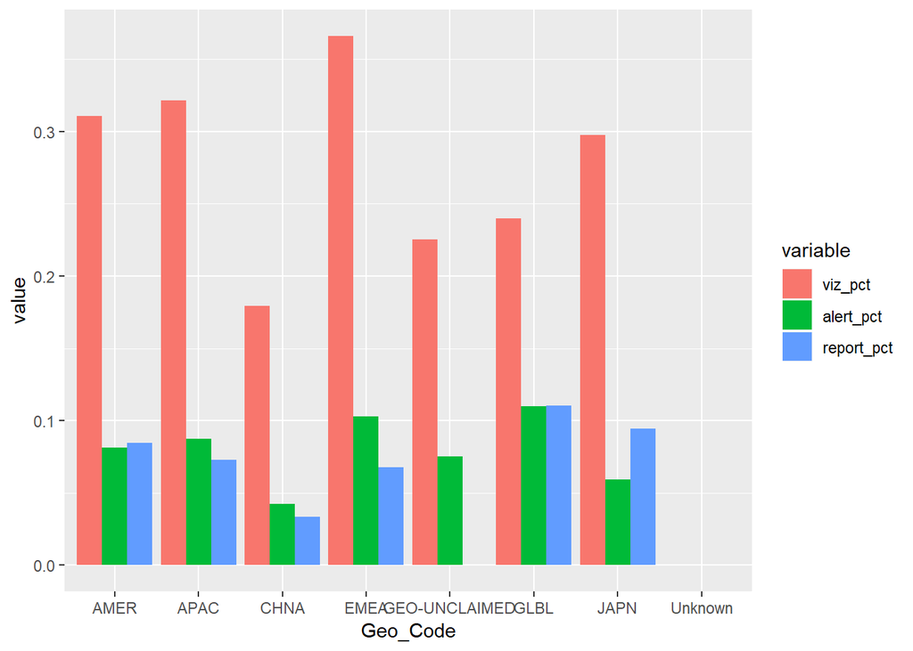

```r
ggplot(data = Pct_by_Geo_Code_melt, aes(x = Geo_Code, y = value, fill = variable)) +
  geom_bar(stat = "identity", position = "dodge")
```

## Usage Percentages by age_year

```r
Pct_by_age_year <- full_dta %>%
  group_by(age_year) %>%
  summarise(count = n(),
            viz_yes = sum(Visualize == "Yes"),
            viz_pct = viz_yes / count,
            alert_yes = sum(Alert == "Yes"),
            alert_pct = alert_yes / count,
            report_yes = sum(Report == "Yes"),
            report_pct = report_yes / count)
```

```r
Pct_by_age_year_melt <- melt(Pct_by_age_year, id = "age_year", measure = c("viz_pct", "alert_pct", "report_pct"))
```

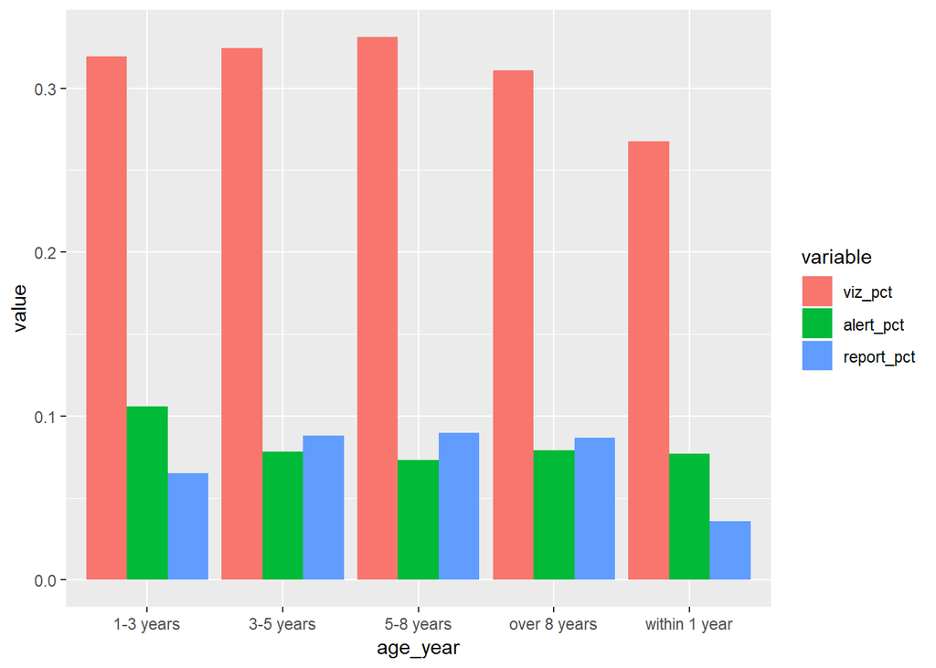

```r
ggplot(data = Pct_by_age_year_melt, aes(x = age_year, y = value, fill = variable)) +
  geom_bar(stat = "identity", position = "dodge")
```

- Members for less than a year tend to use Visualize and Report less than other groups
- Members for 1-3 years are the highest users of Alert
- In general, Report usage increases as a customer is a member for longer

## Visualize by Alert and Report

```r
viz_by_alert_report <- full_dta %>%
  group_by(Visualize) %>%
  summarise(count = n(),
            alert_yes = sum(Alert == "Yes"),
            alert_pct = alert_yes / count,
            report_yes = sum(Report == "Yes"),
            report_pct = report_yes / count)
```

```r
viz_by_alert_report_melt <- melt(viz_by_alert_report, id = "Visualize", measure = c("alert_pct", "report_pct"))
```

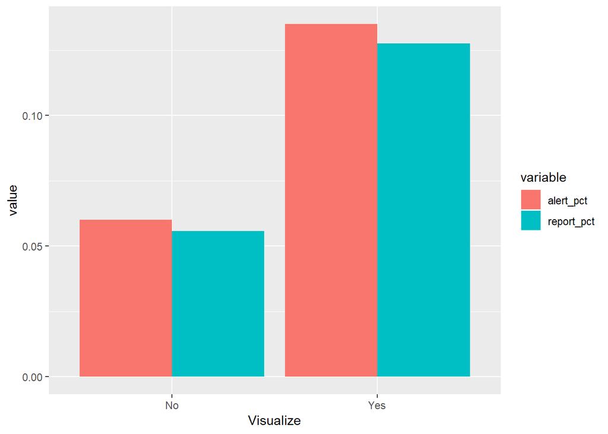

```r
ggplot(data = viz_by_alert_report_melt, aes(x = Visualize, y = value, fill = variable)) +
  geom_bar(stat = "identity", position = "dodge")
```

- Customers who use Visualize are more likely to use Alert and Report

## Alert by Visualize and Report

```r
alert_by_viz_report <- full_dta %>%
  group_by(Alert) %>%
  summarise(count = n(),
            viz_yes = sum(Visualize == "Yes"),
            viz_pct = viz_yes / count,
            report_yes = sum(Report == "Yes"),
            report_pct = report_yes / count)
```

```r
alert_by_viz_report_melt <- melt(alert_by_viz_report, id = "Alert", measure = c("viz_pct", "report_pct"))
```

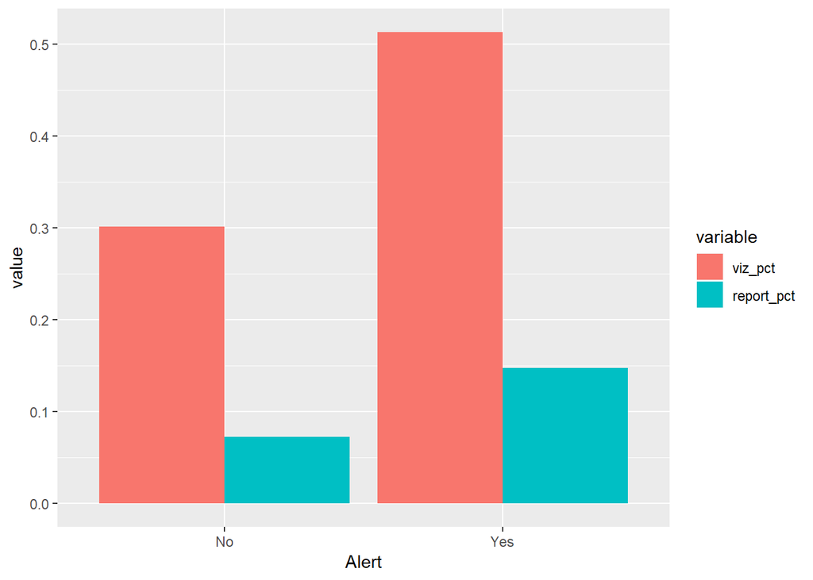

```r
ggplot(data = alert_by_viz_report_melt, aes(x = Alert, y = value, fill = variable)) +
  geom_bar(stat = "identity", position = "dodge")
```

- Customers who use Alert are more likely to use Visualize and Report

## Report by Visualize and Report

```r
report_by_viz_alert <- full_dta %>%
  group_by(Report) %>%
  summarise(count = n(),
            viz_yes = sum(Visualize == "Yes"),
            viz_pct = viz_yes / count,
            alert_yes = sum(Alert == "Yes"),
            alert_pct = alert_yes / count)
```

```r
report_by_viz_alert_melt <- melt(report_by_viz_alert, id = "Report", measure = c("viz_pct", "alert_pct"))
```

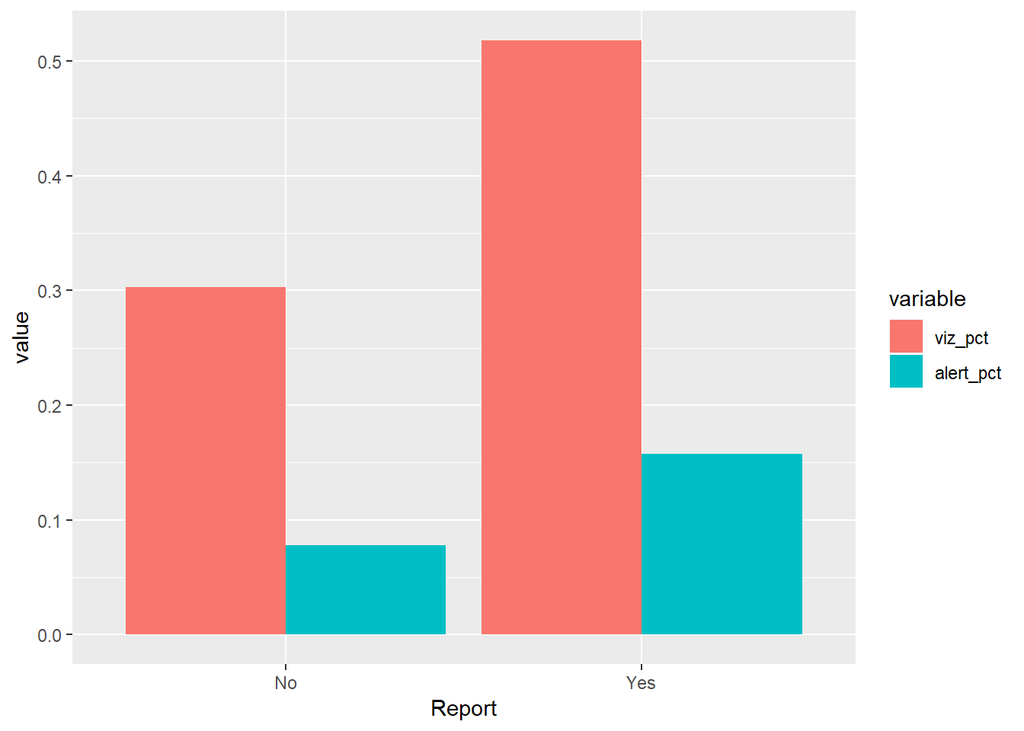

```r
ggplot(data = report_by_viz_alert_melt, aes(x = Report, y = value, fill = variable)) +
  geom_bar(stat = "identity", position = "dodge")
```

- Customers who use Report are more likely to use Visualize and Alert

# What percentage of customers fit into each category of Visualize, Alert, Report

```r
viz_alert_report_pct <- full_dta %>%
  group_by(Visualize, Alert, Report) %>%
  summarise(count = n(),
            pct_of_customer = (count / 1634886) * 100)
```

# Looking at trends by month

## First group by Customer_ID and month

```r
cust_id_groups <- full_dta %>%
  group_by(Customer_ID, Month, Customer_size, Geo_Code, Visualize, Alert, Report, age_year) %>%
  summarise(count_products = n(),
            total_billed = sum(Billed_amount))
```

```r
cust_id_groups %>%
  group_by(Month) %>%
  summarise(total_customers = n(),
            total_billed_amt = sum(total_billed),
            viz_pct = (sum(Visualize == "Yes") / total_customers) * 100,
            alert_pct = (sum(Alert == "Yes") / total_customers) * 100,
            report_pct = (sum(Report == "Yes") / total_customers) * 100)
```

| Month | total_customers | total_billed_amt | viz_pct | alert_pct | report_pct |
| --- | --- | --- | --- | --- | --- |
| April-19 | 45604 | 213655391 | 26.01088 | 6.047715 | 5.547759 |
| June-19 | 47145 | 225694646 | 24.71100 | 6.412133 | 6.055785 |
| May-19 | 47269 | 225292652 | 26.10590 | 6.249339 | 5.735260 |

# Product Matrix

## Use all three products

```r
sum(cust_id_groups$Visualize == "Yes" & cust_id_groups$Alert == "Yes" & cust_id_groups$Report == "Yes")
```

```
## [1] 655
```

- 0.5% use all three products

## Use two of three products

```r
sum(cust_id_groups$Visualize == "Yes" & cust_id_groups$Alert == "Yes" & cust_id_groups$Report == "No")
```

```
## [1] 3393
```

```r
sum(cust_id_groups$Visualize == "Yes" & cust_id_groups$Alert == "No" & cust_id_groups$Report == "Yes")
```

```
## [1] 3107
```

```r
sum(cust_id_groups$Visualize == "No" & cust_id_groups$Alert == "Yes" & cust_id_groups$Report == "Yes")
```

```
## [1] 378
```

- Total is 6878
- 4.9% use two of three products

## Use one of three products

```r
sum(cust_id_groups$Visualize == "Yes" & cust_id_groups$Alert == "No" & cust_id_groups$Report == "No")
```

```
## [1] 28697
```

```r
sum(cust_id_groups$Visualize == "No" & cust_id_groups$Alert == "Yes" & cust_id_groups$Report == "No")
```

```
## [1] 4309
```

```r
sum(cust_id_groups$Visualize == "No" & cust_id_groups$Alert == "No" & cust_id_groups$Report == "Yes")
```

```
## [1] 3956
```

- 36962
- 26.4% use one of three products

## Use none of three products

```r
sum(cust_id_groups$Visualize == "No" & cust_id_groups$Alert == "No" & cust_id_groups$Report == "No")
```

```
## [1] 95523
```

- 68.2% use none of three products

# Looking at anomalies in billing data

```r
summary(cust_id_groups$total_billed)
```

```
##    Min. 1st Qu.  Median    Mean 3rd Qu.    Max.
##       0    1433    2272    4747    4520  919031
```

```r
sum(cust_id_groups$total_billed == 0)
```

```
## [1] 14
```

```r
free_month <- subset(cust_id_groups, total_billed == 0)
```

```r
sum(full_dta$Billed_amount <= 0)
```

```
## [1] 487999
```

```r
sum(cust_id_groups$total_billed > 275000)
```

```
## [1] 15
```

```r
high_billing <- subset(cust_id_groups, total_billed > 275000)
```

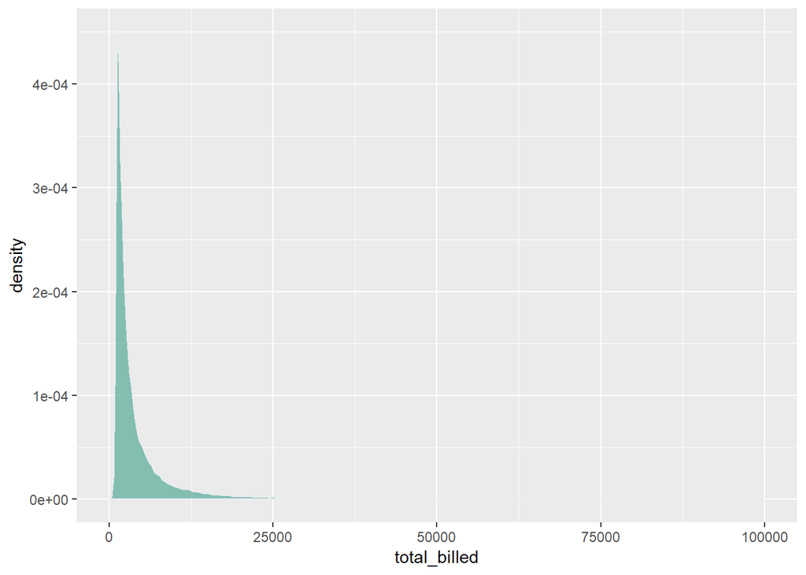

```r
cust_id_groups %>%
  filter(total_billed < 100000) %>%
  ggplot(aes(x = total_billed)) +
  geom_density(fill="#69b3a2", color="#e9ecef", alpha=0.8)
```

# Product Usage by Customer Size for Presentation

```r
Pct_by_Customer_size <- full_dta %>%
  group_by(Customer_size) %>%
  summarise(count = n(),
            viz_yes = sum(Visualize == "Yes"),
            Visualize = (viz_yes / count) * 100,
            alert_yes = sum(Alert == "Yes"),
            Alert = (alert_yes / count) * 100,
            report_yes = sum(Report == "Yes"),
            Report = (report_yes / count) * 100)
```

```r
Pct_by_Customer_size_melt <- melt(Pct_by_Customer_size, id = "Customer_size", measure = c("Visualize", "Alert", "Report"))
```

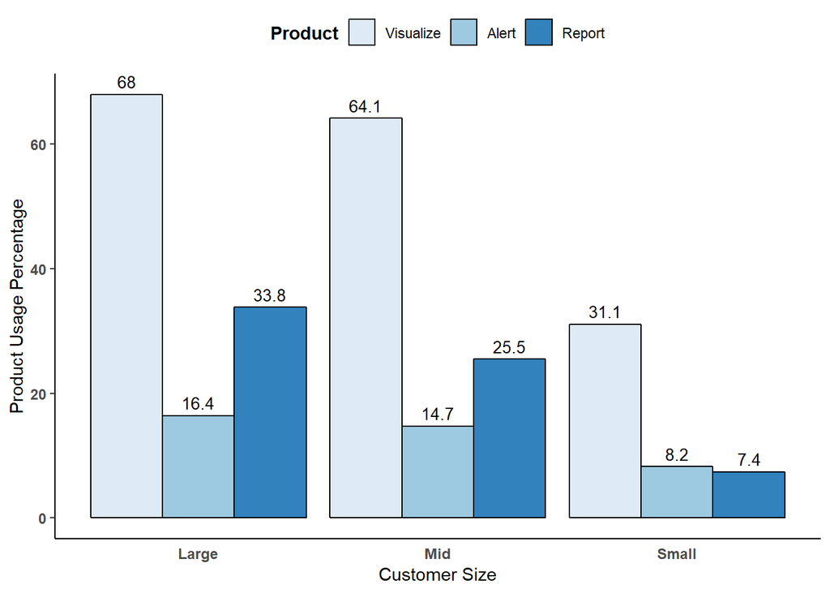

```r
ggplot(data = Pct_by_Customer_size_melt, aes(x = Customer_size, y = value, fill = variable)) +
  geom_bar(stat = "identity", position = "dodge", colour = "black") +
  theme_classic() +
  labs(fill = "Product") +
  xlab("Customer Size") +
  ylab("Product Usage Percentage") +
  theme(axis.text = element_text(face = "bold", size = 9),
        axis.ticks.x = element_blank(),
        legend.position = "top",
        legend.title = element_text(face = "bold")) +
  scale_fill_brewer(palette = "Blues") +
  geom_text(aes(label = round(value, 1)), vjust = -0.5, color = "black",
            position = position_dodge(.9), size = 3.5)
```